# Sleep Health and Lifestyle Dataset

The sleep Health and Lifestyle dataset contains 374 rows and 13 columns, covering a wide range of variables related to sleep and daily habits. It includes details such as gender, age, physical activity, stress level, BMI category, blood preassure, heart rate, daily steps, and the presence or abscence of sleep disorders.

We have the data of 374 people and there lifestyle and were going to abserve who sleeps the best and who sleeps the worst.

## Below this is the data of the first 5 people just to see if its working prperly.(test run)

```python
#import matplotlib and pandas
import pandas as pd
import matplotlib.pyplot as plt
# Display 5 columns in the DataFrame
df = pd.read_csv("data/Sleep_health_and_lifestyle_dataset.csv")
df.head()
```

|  | Person ID | Gender | Age | Occupation | Sleep Duration | Quality of Sleep | Physical Activity Level | Stress Level | BMI Category | Blood Pressure | Heart Rate | Daily Steps | Sleep Disorder |
| --- | --- | --- | --- | --- | --- | --- | --- | --- | --- | --- | --- | --- | --- |
| 0 | 1 | Male | 27 | Software Engineer | 6.1 | 6 | 42 | 6 | Overweight | 126/83 | 77 | 4200 | NaN |
| 1 | 2 | Male | 28 | Doctor | 6.2 | 6 | 60 | 8 | Normal | 125/80 | 75 | 10000 | NaN |
| 2 | 3 | Male | 28 | Doctor | 6.2 | 6 | 60 | 8 | Normal | 125/80 | 75 | 10000 | NaN |
| 3 | 4 | Male | 28 | Sales Representative | 5.9 | 4 | 30 | 8 | Obese | 140/90 | 85 | 3000 | Sleep Apnea |
| 4 | 5 | Male | 28 | Sales Representative | 5.9 | 4 | 30 | 8 | Obese | 140/90 | 85 | 3000 | Sleep Apnea |

## Dataset Information

```python
# Dataset information
df.dtypes
```

```
Person ID                    int64
Gender                      object
Age                          int64
Occupation                  object
Sleep Duration             float64
Quality of Sleep             int64
Physical Activity Level      int64
Stress Level                 int64
BMI Category                object
Blood Pressure              object
Heart Rate                   int64
Daily Steps                  int64
Sleep Disorder              object
dtype: object
```

## Does Occupation affect how much sleep you get?

First were going to see if occupation has anything to do in how much you get to sleep. We're going to see which occupation sleeps the most and which gets the lest sleep

AS you can see below if we go based of occupation an Engeneer sleeps the most with an average of 7.9 hours a day and the quality of sleep is an 8 out of 10. The occupation with the least amount of sleep is a sales representative with an average of 5.9 hours of sleep, and a 4 out of 10 for quality of sleep.

```python
# Showing how much each occupation sleeps
occupation_sleep_stats = df.groupby('Occupation')[['Sleep Duration', 'Quality of Sleep']].mean().sort_values(by='Sleep Duration', ascending=False)
print(occupation_sleep_stats)
```

```
                      Sleep Duration  Quality of Sleep
Occupation
Engineer                    7.987302          8.412698
Lawyer                      7.410638          7.893617
Accountant                  7.113514          7.891892
Nurse                       7.063014          7.369863
Doctor                      6.970423          6.647887
Manager                     6.900000          7.000000
Software Engineer           6.750000          6.500000
Teacher                     6.690000          6.975000
Salesperson                 6.403125          6.000000
Scientist                   6.000000          5.000000
Sales Representative        5.900000          4.000000
```

## Below is the number of people that work in each field

```python
# Different occupations in the dataset
occupation_counts = df['Occupation'].value_counts()
print(occupation_counts)
```

```
Occupation
Nurse                   73
Doctor                  71
Engineer                63
Lawyer                  47
Teacher                 40
Accountant              37
Salesperson             32
Scientist                4
Software Engineer        4
Sales Representative     2
Manager                  1
Name: count, dtype: int64
```

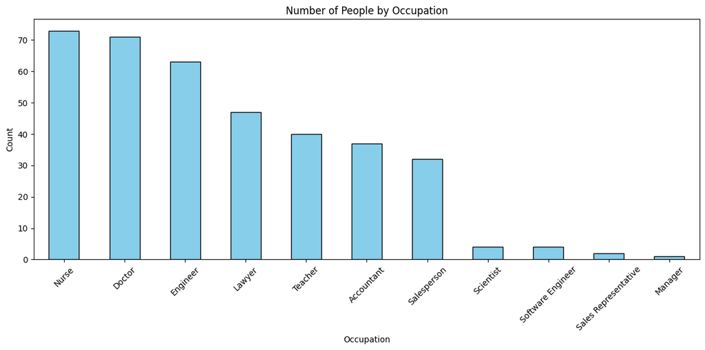

```python
# Plot a bar graph of people's occupations
plt.figure(figsize=(12, 6))
occupation_counts.plot(kind='bar', color='skyblue', edgecolor='black')
plt.title('Number of People by Occupation')
plt.xlabel('Occupation')
plt.ylabel('Count')
plt.xticks(rotation=45)
plt.tight_layout()
plt.show()
```

## Does getting enough sleep affect your health?

Now we're going to see the person with the most sleep and the person that gets the least sleep and compare the data

The person with the most sleep is much more healthier her BMI is normal, her heart rate is 65, and she does not have a sleep disorder. On the other hand the person with the least sleep is overweight, her heart rate is 81, and she has a sleep disorder. She is far less healthier than the person that gets the most sleep. We can conclude that if you get a good amount of sleep you're more likely to be healthier.

### Person with the most amount of sleep

```python
# Showing the person with the most sleep duration
max_sleep_row = df['Sleep Duration'].idxmax()
print(f"The row number of the person with the most sleep duration is: {max_sleep_row}")
df.loc[max_sleep_row]
```

```
The row number of the person with the most sleep duration is: 298
```

```
Person ID                       299
Gender                       Female
Age                              51
Occupation                 Engineer
Sleep Duration                  8.5
Quality of Sleep                  9
Physical Activity Level          30
Stress Level                      3
BMI Category                 Normal
Blood Pressure               125/80
Heart Rate                       65
Daily Steps                    5000
Sleep Disorder                  NaN
Name: 298, dtype: object
```

### person with the least amount of sleep

```python
# Showing the person with the least sleep duration
min_sleep_row = df['Sleep Duration'].idxmin()
print(f"The row number of the person with the least sleep duration is: {min_sleep_row}")
df.loc[min_sleep_row]
```

```
The row number of the person with the least sleep duration is: 80
```

```
Person ID                           81
Gender                          Female
Age                                 34
Occupation                   Scientist
Sleep Duration                     5.8
Quality of Sleep                     4
Physical Activity Level             32
Stress Level                         8
BMI Category                Overweight
Blood Pressure                  131/86
Heart Rate                          81
Daily Steps                       5200
Sleep Disorder             Sleep Apnea
Name: 80, dtype: object
```

## DO people with a BMI in the normal range get more sleep than those classified as overweight?

### Below is the overweight BMI category and most people sleep in the 6 to 6.5 range. They get less sleep than the normal BMI category.

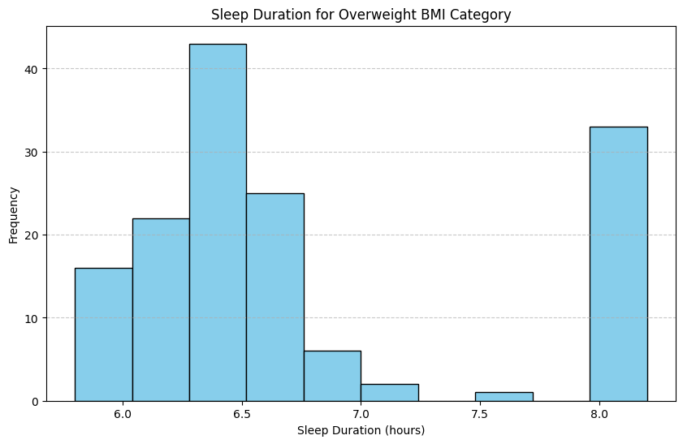

```python
# Filter data for "Overweight" BMI category
overweight_sleep_data = df[df['BMI Category'] == 'Overweight']

# Plot the sleep duration for the "Overweight" BMI category
plt.figure(figsize=(10, 6))
plt.hist(overweight_sleep_data['Sleep Duration'], bins=10, color='skyblue', edgecolor='black')
plt.title('Sleep Duration for Overweight BMI Category')
plt.xlabel('Sleep Duration (hours)')
plt.ylabel('Frequency')
plt.grid(axis='y', linestyle='--', alpha=0.7)
plt.show()
```

### Below is the Normal BMI category and the range is 7-8 hours. With this informatin we can conclude that the Normal BMI category get more sleep.

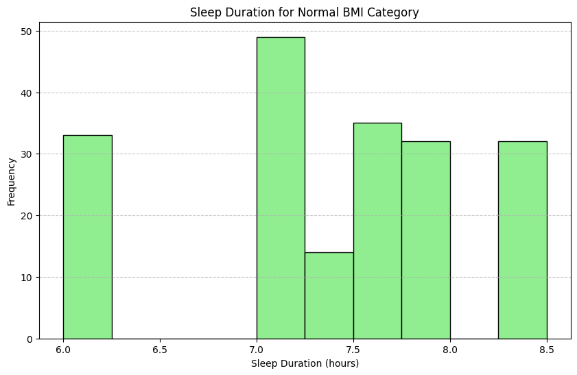

```python
# Import necessary modules
import pandas as pd
import matplotlib.pyplot as plt

# Load the dataset
df = pd.read_csv("data/Sleep_health_and_lifestyle_dataset.csv")

# Filter data for "Normal" BMI category
normal_bmi_sleep_data = df[df['BMI Category'] == 'Normal']

# Plot the sleep duration for the "Normal" BMI category
plt.figure(figsize=(10, 6))
plt.hist(normal_bmi_sleep_data['Sleep Duration'], bins=10, color='lightgreen', edgecolor='black')
plt.title('Sleep Duration for Normal BMI Category')
plt.xlabel('Sleep Duration (hours)')
plt.ylabel('Frequency')
plt.grid(axis='y', linestyle='--', alpha=0.7)
plt.show()
```

## Does a person's BMI get less if they are more engaged in physical activity depending on their occupation?

Figure 1 shows how we classified people's BMI according to their occupation, and Figure 2 shows how much physical activity each occupation contributes to an individual's daily activities. Having already compared the two graphs, we can see that a high level of physical activity does not necessarily translate into a lower BMI. One excellent example is the nursing profession, which, according to the data provided, it has the highest count of overweight individuals as well as the highest levels of physical activity and the categories with normal weight have less physical activity than nurses.

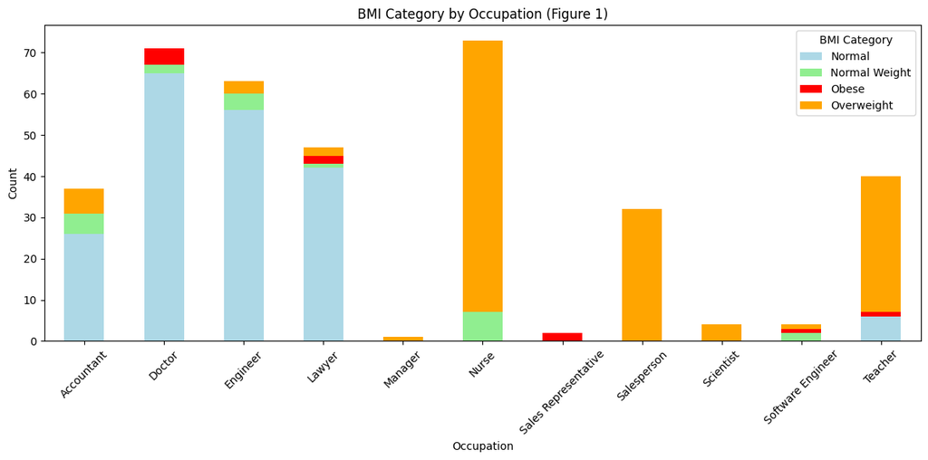

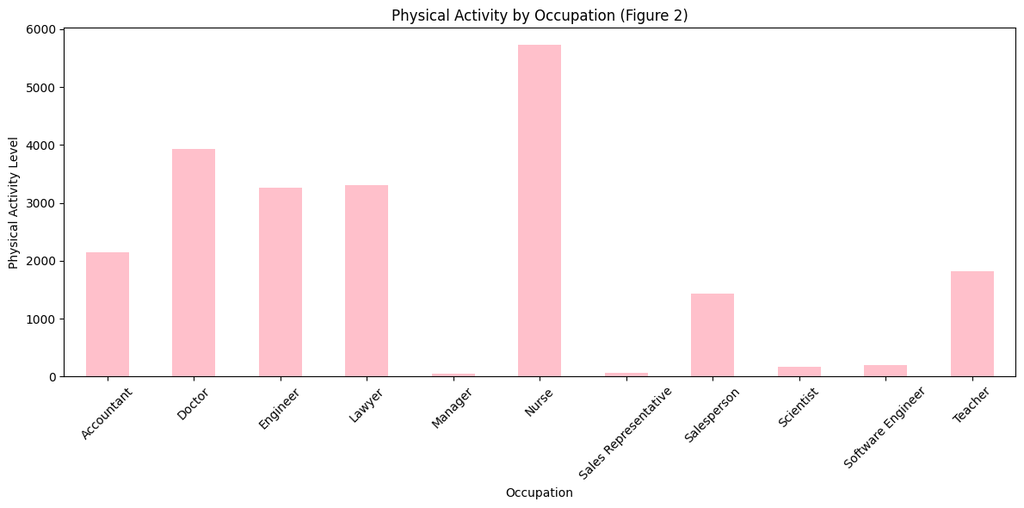

```python
# Bar plot of BMI category by occupation
bmi_by_occupation.plot(kind='bar', figsize=(12, 6), stacked=True, color=['lightblue', 'lightgreen', 'red', 'orange'])
plt.title('BMI Category by Occupation (Figure 1)')
plt.xlabel('Occupation')
plt.ylabel('Count')
plt.xticks(rotation=45)
plt.legend(title='BMI Category')
plt.tight_layout()
plt.show()

# Bar plot of physical activity by occupation
physical_activity_by_occupation.plot(kind='bar', figsize=(12, 6), color='pink')
plt.title('Physical Activity by Occupation (Figure 2)')
plt.xlabel('Occupation')
plt.ylabel('Physical Activity Level')
plt.xticks(rotation=45)
plt.tight_layout()
plt.show()
```

## Do men and women find the same occupation to be stressful? Or does it vary according on the gender?

We want to determine if men and women feel the same job to be stressful by comparing the stress levels of the same occupations they performed. In order to accomplish this, we are gathering data for both sexes in these pie charts, and based on the percentages, we can observe that they find the same job to be stressful but males have two occupations that are high average. The highest percentage of occupation for women is teaching, at 25%, whereas the highest for men are teaching and accounting, at 21.4%. (Since there are more females in the dataset they have a higher percentage but that shouldn't affect the results because we want to check what job has the highest percanatge individually)

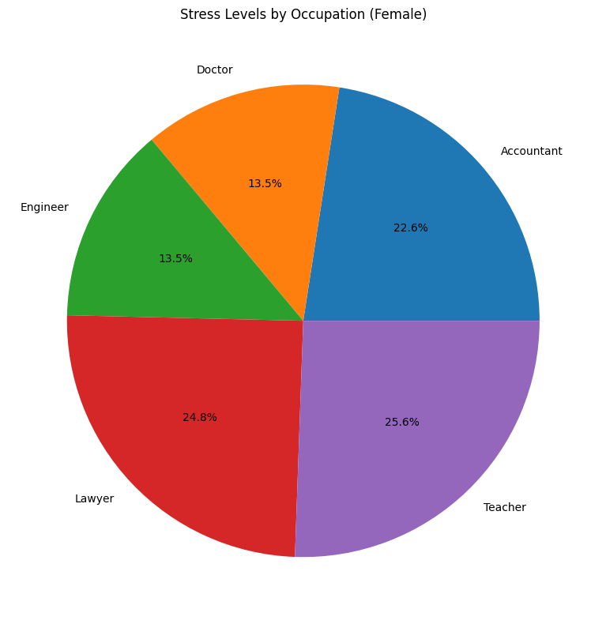

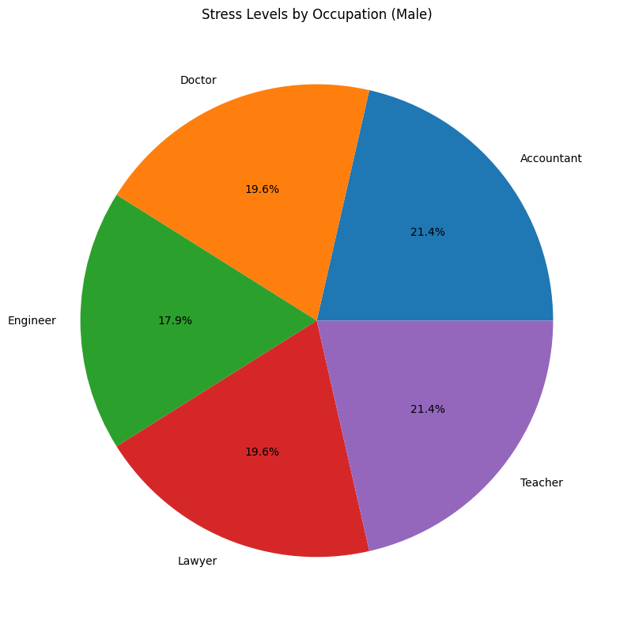

```python
# Filter to include only common occupations
common_occupations = female_stress.index.intersection(male_stress.index)

female_stress_common = female_stress[common_occupations]
male_stress_common = male_stress[common_occupations]

# Pie chart for female stress levels by common occupations
female_stress_common.plot(kind='pie', autopct='%1.1f%%', figsize=(8, 8), title='Stress Levels by Occupation (Female)', ylabel='')
plt.tight_layout()
plt.show()

# Pie chart for male stress levels by common occupations
male_stress_common.plot(kind='pie', autopct='%1.1f%%', figsize=(8, 8), title='Stress Levels by Occupation (Male)', ylabel='')
plt.tight_layout()
plt.show()
```

## What occupation has the highest blood pressure?

In this problem we're making a list of what occupation has the highest blood pressure starting from 0 through 10. According to the data the job with the worse blood pressure is the nurse with a 116.12 average and the job with the best is an accountant with a 97.32 average. (Kind of ironic that the nurse would be the one with the highest average)

```python
# Split the Blood Pressure column into systolic and diastolic values
df[['Systolic', 'Diastolic']] = df['Blood Pressure'].str.split('/', expand=True).astype(int)

# Calculate the average blood pressure for each occupation
avg_blood_pressure_by_occupation = df.groupby('Occupation')[['Systolic', 'Diastolic']].mean()
avg_blood_pressure_by_occupation['Average BP'] = (avg_blood_pressure_by_occupation['Systolic'] + avg_blood_pressure_by_occupation['Diastolic']) / 2

# Sort occupations by the worst average blood pressure
worst_blood_pressure_occupations = avg_blood_pressure_by_occupation.sort_values(by='Average BP', ascending=False)

# Create a ranked list of occupations
ranked_occupations = worst_blood_pressure_occupations.reset_index()

print(ranked_occupations[['Occupation', 'Average BP']])
```

```
              Occupation  Average BP
0                  Nurse  116.123288
1   Sales Representative  115.000000
2                Teacher  109.062500
3              Scientist  107.500000
4            Salesperson  107.500000
5                 Lawyer  107.478723
6      Software Engineer  104.875000
7               Engineer  103.642857
8                Manager  103.500000
9                 Doctor  101.753521
10            Accountant   97.324324
```

## Are the younger or older age group more physically active?

The data indicates that people in their 40s and 50s engage in more physical activity than people in their 20s and 30s. Although their work and health categories are hidden, we can still determine which age group engages in the most physical activity: 40-year-olds have the highest level of physical activity of any group, exceeding 70, while 20-year-olds have the lowest level, at 50.

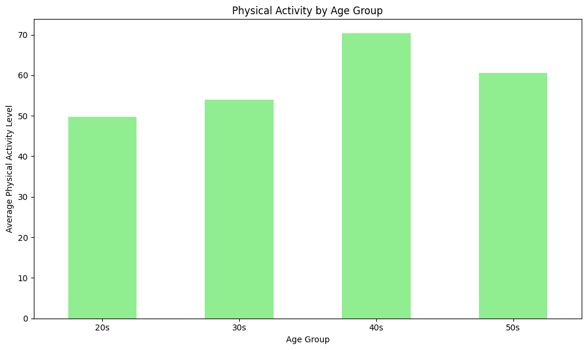

```python
# Plot the average physical activity by age group
physical_activity_by_age_group.plot(kind='bar', color='lightgreen', figsize=(10, 6))
# Set the title and labels
plt.title('Physical Activity by Age Group')
plt.xlabel('Age Group')
plt.ylabel('Average Physical Activity Level')
plt.xticks(rotation=0)
plt.tight_layout()
plt.show()
```

## Top 5 healthiest and least healthy individuals

```python
# Sort healthiest individuals by Quality of Sleep, Stress Level, and Blood Pressure
top_5_healthiest = healthiest_individuals.sort_values(
    by=['Quality of Sleep', 'Stress Level', 'Systolic', 'Diastolic'],
    ascending=[False, True, True, True]
).head(5)

# Sort unhealthiest individuals by reversing the criteria
top_5_unhealthiest = df.sort_values(
    by=['Quality of Sleep', 'Stress Level', 'Systolic', 'Diastolic'],
    ascending=[True, False, False, False]
).head(5)

# Display the results
print("Top 5 Healthiest Individuals:")
print(top_5_healthiest[['Person ID', 'Gender', 'Age', 'Occupation', 'Stress Level', 'Quality of Sleep', 'Blood Pressure']])

print("\nTop 5 Unhealthiest Individuals:")
print(top_5_unhealthiest[['Person ID', 'Gender', 'Age', 'Occupation', 'Stress Level', 'Quality of Sleep', 'Blood Pressure']])
```

```
Top 5 Healthiest Individuals:
     Person ID  Gender  Age  Occupation  Stress Level  Quality of Sleep  \
149        150  Female   39  Accountant             3                 9
150        151  Female   39  Accountant             3                 9
341        342  Female   56      Doctor             3                 9
342        343  Female   56      Doctor             3                 9
85          86  Female   35  Accountant             4                 8

    Blood Pressure
149         115/78
150         115/78
341         118/75
342         118/75
85          115/75

Top 5 Unhealthiest Individuals:
    Person ID  Gender  Age            Occupation  Stress Level  \
3           4    Male   28  Sales Representative             8
4           5    Male   28  Sales Representative             8
5           6    Male   28     Software Engineer             8
80         81  Female   34             Scientist             8
81         82  Female   34             Scientist             8

    Quality of Sleep Blood Pressure
3                  4         140/90
4                  4         140/90
5                  4         140/90
80                 4         131/86
81                 4         131/86
```